## Data description and loading

In this study a hierarchical modeling framework is used to disentangle the toxicity of complex metal mixtures by carrying out a screening study of 92 drinking well water samples containing multiple metal elements. The main objective of this study is to determine the neurodevelopmental impacts from exposure to these drinking water samples. This is achieved by carrying out a larvel zebrafish assay.

```r
library(readxl)
library(dplyr)
library(car)
library(ggplot2)
```

```r
file_path <- "data/average_swims.xlsx"
metal_conc <- read_excel(file_path, sheet = 1)
larvel_activity_data <- read_excel(file_path, sheet = 2)
colnames(larvel_activity_data)[colnames(larvel_activity_data) == "Sample"] <- "Sample_No"
larvel_data <- larvel_activity_data %>%
  left_join(metal_conc %>% select(-CCU), by = "Sample_No")
```

```r
file_path <- "data/average_swims.xlsx"
metal_conc <- read_excel(file_path, sheet = 1)
larvel_activity_data <- read_excel(file_path, sheet = 2)
colnames(larvel_activity_data)[colnames(larvel_activity_data) == "Sample"] <- "Sample_No"
larvel_data <- larvel_activity_data %>%
  left_join(metal_conc %>% select(-CCU), by = "Sample_No")
```

The variables within the data set are as follows :

```
 [1] "Sample_No"            "Fish"                 "Time"
 [4] "Dark/Light"           "DLCondition"          "AVG_Distance"
 [7] "AVG_Distance_Control" "Control_Distance"     "Be"
[10] "Cr"                   "Mn"                   "Fe"
[13] "Ni"                   "Cu"                   "As"
[16] "Se"                   "Cd"                   "Sb"
[19] "Ba"                   "Tl"                   "Pb"
[22] "U"
```

```
# A tibble: 6 × 22
  Sample_No  Fish  Time `Dark/Light` DLCondition AVG_Distance
      <dbl> <dbl> <dbl> <chr>              <dbl>        <dbl>
1         1   539     5 D                      1         445.
2         1   539    10 L                      0         772.
3         1   539    15 D                      1         902.
4         1   539    20 L                      0         648.
5         1   539    25 D                      1         913.
6         1   540     5 D                      1         486.
# ℹ 16 more variables: AVG_Distance_Control <dbl>, Control_Distance <dbl>,
#   Be <dbl>, Cr <dbl>, Mn <dbl>, Fe <dbl>, Ni <dbl>, Cu <dbl>, As <dbl>,
#   Se <dbl>, Cd <dbl>, Sb <dbl>, Ba <dbl>, Tl <dbl>, Pb <dbl>, U <dbl>
```

- Sample_No - There are 92 well water samples
- Fish - To each well water sample 24 zebrafish larvae are introduced
- Time - The distance each fish swims is recorded in intervals of 5 for 25 minutes.
- Dark/Light - Each 5 minute intervals are in dark or light coditions alternatively.
- DLCondition - 1 for dark and 0 for light.
- AVG_Distance - Records the distances traveled by the larvae in each time interval.
- AVG_Distance_Control - Records the distances traveled by the larvae relative to control samples in each time interval.
- Control_Distance - Records the distances traveled by the larvae in control samples during each time interval.
- The concentration of 14 metals in each water sample is also recorded.

## Linear Mixed Model Fitted in the study

This LMM is fitted including **time** as a random slope.

```r
library(lmerTest) # to fit a LMM
library(lme4)
```

$Y^*_{ijt}$ stands for $i$th zebra fish in $j$th well water sample during $t$th time interval. $k$ stands for the metal type.

$$Y^*_{ijt} = \beta_0 + \beta_1 L_{ijt} + \beta_2 \text{Time}_{ijt} +
\sum_k \beta_k X_{jk} + u_{0ij} + u_{1ij} Time_{ijt} + u_{2ij} L_{ijt} +
u_{3j} + e_{ijt}$$
Model Assumptions:
$$\begin{pmatrix}
u_{0ij} \\
u_{1ij} \\
u_{2ij}
\end{pmatrix}
\sim \mathcal{N}_3(
\begin{pmatrix}
0 \\
0 \\
0
\end{pmatrix}
,
\begin{pmatrix}
\sigma_0^2 & \sigma_{01} & \sigma_{02} \\
\sigma_{10} & \sigma_1^2 & \sigma_{12} \\
\sigma_{20} & \sigma_{21} & \sigma_2^2
\end{pmatrix})$$

$$u_{2j} \sim \mathcal{N}(0, \sigma_3^2)$$

$$e_{ijt} \sim \mathcal{N}(0, \sigma_e^2)$$

```
Linear mixed model fit by maximum likelihood . t-tests use Satterthwaite's
  method [lmerModLmerTest]
Formula:
AVG_Distance_Control ~ Time + DLCondition + U + (1 + Time + DLCondition |
    Fish) + (1 | Sample_No)
   Data: larvel_data

     AIC      BIC   logLik deviance df.resid
130958.8 131045.0 -65467.4 130934.8     9733

Scaled residuals:
    Min      1Q  Median      3Q     Max
-5.1642 -0.3277 -0.0295  0.2932  5.6856

Random effects:
 Groups    Name        Variance Std.Dev. Corr
 Fish      (Intercept) 59606.51 244.144
           Time           95.18   9.756  -0.43
           DLCondition 19464.02 139.514  -0.07 -0.06
 Sample_No (Intercept) 24709.87 157.194
 Residual              15191.22 123.253
Number of obs: 9745, groups:  Fish, 1949; Sample_No, 92

Fixed effects:
              Estimate Std. Error         df t value Pr(>|t|)
(Intercept)   34.97369   17.91150   97.96780   1.953   0.0537 .
Time          -1.78004    0.28286 1949.07579  -6.293 3.84e-10 ***
DLCondition   22.28814    4.05980 1949.06169   5.490 4.55e-08 ***
U              0.09471    0.04938   86.73606   1.918   0.0584 .
---
Signif. codes:  0 '***' 0.001 '**' 0.01 '*' 0.05 '.' 0.1 ' ' 1

Correlation of Fixed Effects:
            (Intr) Time   DLCndt
Time        -0.195
DLCondition -0.070 -0.035
U           -0.159  0.000  0.000
optimizer (nloptwrap) convergence code: 0 (OK)
Model failed to converge with max|grad| = 0.0204173 (tol = 0.002, component 1)
```

It is evident that the above model does not converge. This is because of the large differences in variance between the random slope time ($u_{1ij} Time_{ijt}$), and the other parameters.

The plots below are used to verify if the assumptions of the Linear Mixed Model are satisfied, it is evident that the assumptions are also not satisfied.

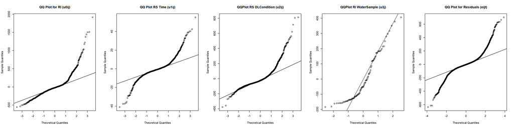

#### simplify code generation :

```r
# Metals to consider
metals <- c("Be", "Cr", "Mn", "Fe", "Ni", "Cu", "As", "Se", "Cd", "Sb", "Ba", "Tl", "Pb", "U")

# Create a data frame to store results
results <- data.frame(
  Metal = character(),
  Conditional_R2 = numeric(),
  Marginal_R2 = numeric(),
  AIC = numeric(),
  BIC = numeric(),
  P_Value = numeric(),
  stringsAsFactors = FALSE
)

# Loop through each metal and fit the model
for (metal in metals) {
  # Dynamically create the formula with the current metal
  formula <- as.formula(
    paste("AVG_Distance1 ~ Time + DLCondition +", metal,
          "+ (1 + DLCondition | Fish) + (1 | Sample_No)")
  )


  # Fit the model
  model <- lmer(formula, data = larvel_data, REML = FALSE)

  # Extract model metrics
  conditional_r2 <- round(r.squaredGLMM(model)[2], 4)
  marginal_r2 <- round(r.squaredGLMM(model)[1], 4)
  aic <- AIC(model0)
  bic <- BIC(model0)

  # Extract the p-value for the metal
  p_value <- summary(model0)$coefficients[metal, "Pr(>|t|)"]

  # Append results to the results data frame
  results <- rbind(
    results,
    data.frame(
      Metal = metal,
      Conditional_R2 = conditional_r2,
      Marginal_R2 = marginal_r2,
      AIC = aic,
      BIC = bic,
      P_Value = p_value
    )
  )
}

# View the results
print(results)
```

[output not shown]

## Linear Mixed Model - excluding **time** as a random slope

$$Y^*_{ijt} = \beta_0 + \beta_1 L_{ijt} + \beta_2 \text{Time}_{ijt} +
\sum_k \beta_k X_{jk} + u_{0ij} + u_{1ij} L_{ijt} + u_{2j} + e_{ijt}$$

Model Assumptions:
$$\begin{pmatrix}
u_{0ij} \\
u_{1ij}
\end{pmatrix}
\sim \mathcal{N}_2(
\begin{pmatrix}
0 \\
0
\end{pmatrix}
,
\begin{pmatrix}
\sigma_0^2 & \sigma_{01} \\
\sigma_{10} & \sigma_1^2
\end{pmatrix})$$

$$u_{2j} \sim \mathcal{N}(0, \sigma_3^2)$$

$$e_{ijt} \sim \mathcal{N}(0, \sigma_e^2)$$

```
Linear mixed model fit by maximum likelihood . t-tests use Satterthwaite's
  method [lmerModLmerTest]
Formula: AVG_Distance_Control ~ Time + DLCondition + U + (1 + DLCondition |
    Fish) + (1 | Sample_No)
   Data: larvel_data

     AIC      BIC   logLik deviance df.resid
131604.5 131669.2 -65793.3 131586.5     9736

Scaled residuals:
    Min      1Q  Median      3Q     Max
-6.0517 -0.3735 -0.0419  0.3232  7.2167

Random effects:
 Groups    Name        Variance Std.Dev. Corr
 Fish      (Intercept) 46401    215.4
           DLCondition 12856    113.4    0.02
 Sample_No (Intercept) 25219    158.8
 Residual              23123    152.1
Number of obs: 9745, groups:  Fish, 1949; Sample_No, 92

Fixed effects:
              Estimate Std. Error         df t value Pr(>|t|)
(Intercept)   34.73206   18.04120   97.65132   1.925   0.0571 .
Time          -1.78004    0.21784 5846.99866  -8.171 3.71e-16 ***
DLCondition   22.28814    4.05990 1949.00664   5.490 4.55e-08 ***
U              0.09016    0.04988   87.31632   1.808   0.0741 .
---
Signif. codes:  0 '***' 0.001 '**' 0.01 '*' 0.05 '.' 0.1 ' ' 1

Correlation of Fixed Effects:
            (Intr) Time   DLCndt
Time        -0.181
DLCondition -0.078  0.000
U           -0.159  0.000  0.000
```

This model converged. However, from the QQ-plots below it is evident that the assumptions are not satisfied.

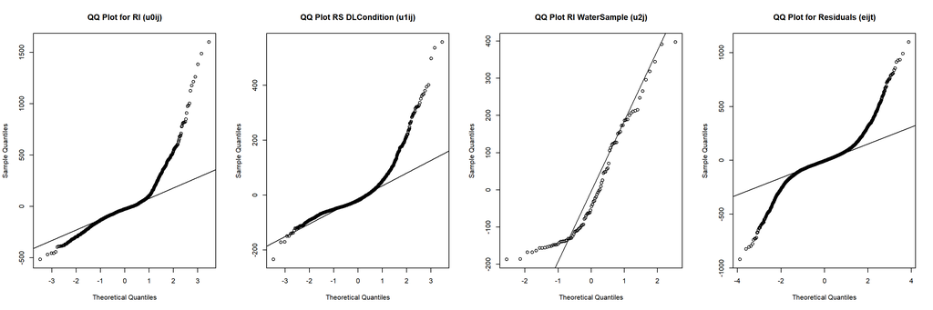

## Exploring Bayesian Linear Mixed Modeling (BLMM) as an alternative modeling strategy

```r
library(brms) # to fit a BLMM
```

### Model 1:

$$u_{2j} \sim \mathcal{N}(0, \sigma_3^2)$$

```r
fit_lin_t <- brm(AVG_Distance ~ Time + DLCondition + Cd + Cu +
                (1 | Fish) +
                (1 | Sample_No),
                data = larvel_data,
                 family = student(),
                 prior = prior(student_t(3, 0, 1), class='b'),
                 seed = 1, refresh = 0)

fit_lin_t

summary(fit_lin_t, waic=TRUE)

LOO(fit_lin_t)
WAIC(fit_lin_t)
pp_check(fit_lin_t, type = "dens_overlay")
pp_check(fit_lin_t, type = "error_hist")

# Visualize marginal effects of predictors
marginal_effects(fit_lin_t)
```

[output not shown]

### Model 2:

$$u_{1j} \sim \mathcal{N}(0, \sigma_1^2)$$

```r
fit_lin_t <- brm(AVG_Distance ~ Time + DLCondition + Cd + Cu +
                (1 | Sample_No),
                data = larvel_data,
                 family = student(),
                 prior = prior(student_t(3, 0, 1), class='b'),
                 seed = 1, refresh = 0)

fit_lin_t

summary(fit_lin_t, waic=TRUE)

LOO(fit_lin_t)
WAIC(fit_lin_t)
pp_check(fit_lin_t, type = "dens_overlay")
pp_check(fit_lin_t, type = "error_hist")

# Visualize marginal effects of predictors
marginal_effects(fit_lin_t)
```

[output not shown]